# A BAYESIAN HIERARCHICAL Model - Ex. 8.4 from P. Hoff’s book

## Bayesian Model

$Y_{ij}$ is the mathscore test of student $i$ in school $j$

$i=1,\ldots, n_j$, $j=1,\ldots,J$, $\quad J=100$ schools

$$\begin{align*}
Y_{1,j},\ldots, Y_{n_j,j} \mid \theta_j &\stackrel{iid}\sim
N(\theta_j,\sigma^2) \qquad \textrm{ within-group model} \quad
j=1,\ldots,J \\
\theta_1,\ldots, \theta_J \mid (\mu,\tau^2) &\stackrel{iid}\sim
N(\mu,\tau^2) \qquad \textrm{ between-group model}\\
(\mu,\tau^2) &\sim \pi
\end{align*}$$

where $\theta_j$ is the parameter expressing the average value of the mathscore in school $j$

$\mu$ is the mean of all $\theta_j$’s, and it is also the mean of all mathscores $Y_{ij}$

```r
# Multilevel data
rm(list=ls())
setwd("/Users/xueyuanhuang/Desktop/R-bayesain/fundamentals")
Y=read.table("school.mathscores.txt")
Y
```

|  | school | mathscore | stu_ses |
| --- | --- | --- | --- |
| 1 | 1 | 52.11 | -0.059948304 |
| 2 | 1 | 57.65 | 1.051652244 |
| 3 | 1 | 66.44 | -0.863514965 |
| 4 | 1 | 44.68 | -0.796551076 |
| 5 | 1 | 40.57 | -1.613510515 |
| 6 | 1 | 35.04 | -1.158156074 |
| 7 | 1 | 50.71 | 0.636476135 |
| 8 | 1 | 66.17 | 0.060586695 |
| 9 | 1 | 39.43 | -1.064406630 |
| 10 | 1 | 46.17 | -1.359047739 |

[output cut: 990 more lines]

```r
dim(Y)
```

```
[1] 1993    3
```

```r
head(Y)
```

|  | school | mathscore | stu_ses |
| --- | --- | --- | --- |
| 1 | 1 | 52.11 | -0.0599483 |
| 2 | 1 | 57.65 | 1.0516522 |
| 3 | 1 | 66.44 | -0.8635150 |
| 4 | 1 | 44.68 | -0.7965511 |
| 5 | 1 | 40.57 | -1.6135105 |
| 6 | 1 | 35.04 | -1.1581561 |

Y scores at the math test for 1993 students in 100 US schools

- First column: **index of the school** of the student
- Second column: **math score of the student**
- Third column: **socio-economic indicator of the student** (not relevant in this class)

Let us compute now the means per school of the math scores:

```r
m = length(unique(Y[,1]))
n<-sv<-ybar<-rep(NA,m)
for(j in 1:m)
{
  ybar[j]<- mean(Y[Y[,1]==j,2]) #empirical mean per group
  sv[j]<-var(Y[Y[,1]==j,2])  #empirical variance per group
  n[j]<-sum(Y[,1]==j)        #frequencies
}
```

Summary of the empirical mathscore means, of the frequencies, of the variances:

```r
cat(paste("Means:", ybar))
```

```
Means: 50.8135483870968 Means: 46.4795454545455 Means: 48.7769565217391 Means: 47.3163157894737 Means: 36.5828571428571 Means: 38.97 Means: 40.418125 Means: 48.85 Means: 49.15625 Means: 41.0683333333333 Means: 57.9481818181818 Means: 50.527 Means: 49.4421052631579 Means: 58.7077777777778 Means: 56.4…
```

```r
cat(paste("Freq:", n))
```

```
Freq: 31 Freq: 22 Freq: 23 Freq: 19 Freq: 21 Freq: 16 Freq: 16 Freq: 22 Freq: 24 Freq: 18 Freq: 11 Freq: 30 Freq: 19 Freq: 18 Freq: 12 Freq: 23 Freq: 7 Freq: 14 Freq: 12 Freq: 20 Freq: 15 Freq: 24 Freq: 14 Freq: 20 Freq: 19 Freq: 30 Freq: 12 Freq: 22 Freq: 20 Freq: 16 Freq: 22 Freq: 15 Freq: 26 Freq…
```

```r
cat(paste("Vars:", sv))
```

```
Vars: 126.568116989247 Vars: 98.3068807359307 Vars: 58.1669675889328 Vars: 112.769080116959 Vars: 69.5113114285714 Vars: 35.8949866666667 Vars: 36.4488429166667 Vars: 123.260895238095 Vars: 57.3395809782609 Vars: 76.160344117647 Vars: 66.1473763636364 Vars: 179.68971137931 Vars: 74.8250730994152 Var…
```

Let’s plot these summaries

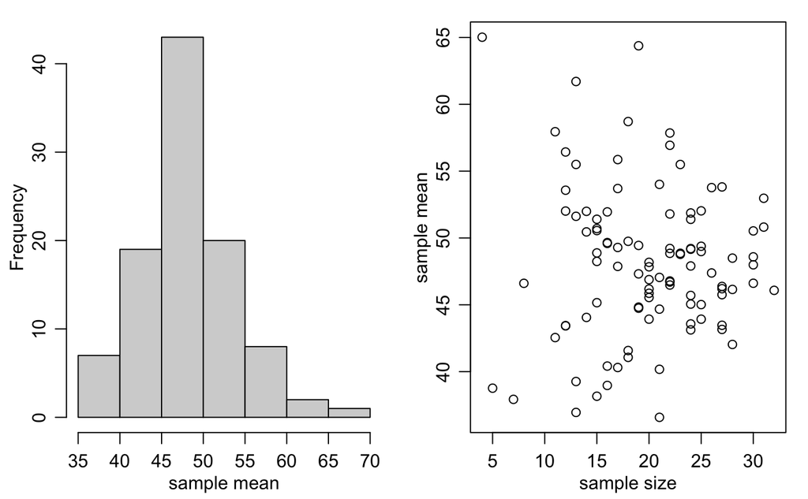

```r
par(mfrow=c(1,2), mar=c(3,3,1,1),mgp=c(1.75,.75,0))

# Plot - sample means
hist(ybar,main="",xlab="sample mean")

# Plot - sample sizes
plot(n,ybar,xlab="sample size",ylab="sample mean")
```

**LEFT**: histogram of the empirical means per school $ybar_j$

**RIGHT**: very extreme sample averages (very small or very large) tend to be associated with schools with small sample size

Remember that, given the same sample mean, the sample var in group $j$ is $\sigma^2/n_j$: the smaller is $n_j$, the larger is the variability of $ybar_j$.

> Parameters of the model are $(\theta_1,\ldots,\theta_{100}, \mu, \tau^2,\sigma^2)$
- $\theta_j$: mean in school $j$;
- $\mu$: grand mean;
- $\tau^2$: variance between schools;
- $\sigma^2$: variance within school $j$ (costant)

The prior for $\theta_1,\ldots,\theta_{100}$ is given by a hierarchy, and it is an exchangeable prior

$$\begin{align*}
\theta_1,\ldots, \theta_J \mid (\mu,\tau^2) &\stackrel{iid}\sim
N(\mu,\tau^2)\\[5pt]
(\mu,\tau^2)&\sim \pi
\end{align*}$$

Then, we assume the following prior for $\sigma^2$, within-group variance (constant in this case, but a more general model with $\sigma_j^2$ can be considered), $\tau^2$, the between-group variance and $\mu$, the grand mean (a priori independent):

$$\begin{align*}
\frac{1}{\sigma^2} &\sim
gamma\left(\frac{\nu_0}{2},\frac{\nu_0\sigma_0^2}{2}\right) \\[5pt]
\frac{1}{\tau^2} &\sim
gamma\left(\frac{\eta_0}{2},\frac{\eta_0\tilde\sigma_0^2}{2}\right)
\\[5pt]
\mu &\sim N\left(\mu_0,\gamma_0^2\right)
\end{align*}$$

Hyperparameters are fixed via **a priori information**:

Hyperparameters of the prior for mu

This is an informative prior, set by info on this type of test administered to the rest of the country

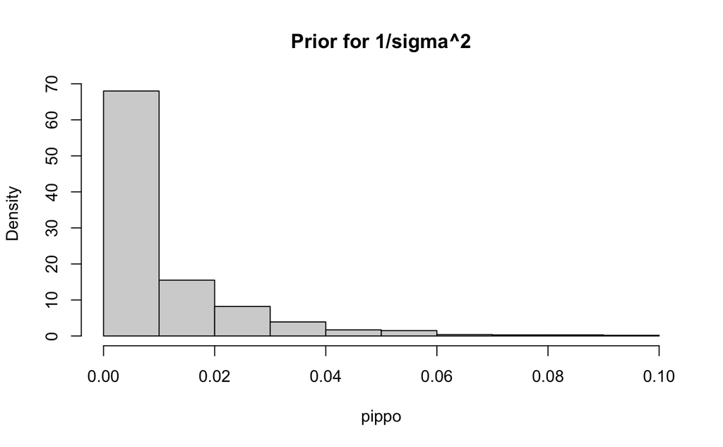

```r
par(mfrow=c(1,1))

# Prior hyperparameters for sigma^2, within-group variance
nu0<-1; s20<-100

# Plot - Prior for 1/sigma^2
pippo=rgamma(1000, shape=nu0/2, rate=nu0/2*s20 )
hist(pippo,prob=T,main='Prior for 1/sigma^2')
```

We compute mean and variance of this prior distribution

```r
cat(paste("Mean:", mean(1/pippo)))
```

```
Mean: 5228912.82453629
```

```r
cat(paste("Var:", var(1/pippo)))
```

```
Var: 25762119958056704
```

Note that both mean and variance of $\sigma^2$ are $+\infty$.

```r
# Prior hyperparameters for tau^2
eta0<-1 ; t20<-100

# Prior hyperparameters for mu
mu0<-50 ; g20<-25
```

## MCMC analysis for the school data

Starting values of the MC & MCMC algorithm:

```r
# Initialize parameters
theta<-ybar
sigma2<-mean(sv)
mu<-mean(theta)
tau2<-var(theta)

# Set random seed and number of iterations
set.seed(1)
S<-3000

# Prepare buffers to store results
THETA<-matrix( nrow=S,ncol=m)
MST<-matrix( nrow=S,ncol=3)

### MCMC algorithm - GIBBS SAMPLER
for(s in 1:S) {

  # sample new values of the thetas
  for(j in 1:m) {
    vtheta<-1/(n[j]/sigma2+1/tau2)
    etheta<-vtheta*(ybar[j]*n[j]/sigma2+mu/tau2)
    theta[j]<-rnorm(1,etheta,sqrt(vtheta))
  }

  # sample new value of sigma2
  nun<-nu0+sum(n)
  ss<-nu0*s20;for(j in 1:m){ss<-ss+sum((Y[Y[,1]==j,2 ]-theta[j])^2)}
  sigma2<-1/rgamma(1,nun/2,ss/2)

  # sample a new value of mu
  vmu<- 1/(m/tau2+1/g20)
  emu<- vmu*(m*mean(theta)/tau2 + mu0/g20)
  mu<-rnorm(1,emu,sqrt(vmu))

  # sample a new value of tau2
  etam<-eta0+m
  ss<- eta0*t20 + sum( (theta-mu)^2 )
  tau2<-1/rgamma(1,etam/2,ss/2)

  # store results
  THETA[s,]<-theta
  MST[s,]<-c(mu,sigma2,tau2)
}
```

- `THETA` contains simulated values for all 100 parameters $\theta_j$’s
- `MST` stores simulated values for $\mu$, $\sigma^2$, $\tau^2$.

**MARGINAL POSTERIOR densities of** $\mu$, $\sigma^2$, $\tau^2$

```r
par(mfrow=c(1,3),mar=c(2.75,2.75,.5,.5),mgp=c(1.7,.7,0))

# Plot - Marginal posterior of mu
plot(density(MST[,1],adj=2),xlab=expression(mu),main="",lwd=2,
ylab=expression(paste(italic("p("),mu,"|",italic(y[1]),"...",italic(y[m]),")")))
abline( v=quantile(MST[,1],c(.025,.5,.975)),col="gray",lty=c(3,2,3) )
```

```r
# Plot - Marginal posterior of sigma^2
plot(density(MST[,2],adj=2),xlab=expression(sigma^2),main="", lwd=2,
ylab=expression(paste(italic("p("),sigma^2,"|",italic(y[1]),"...",italic(y[m]),")")))
abline( v=quantile(MST[,2],c(.025,.5,.975)),col="gray",lty=c(3,2,3) )
```

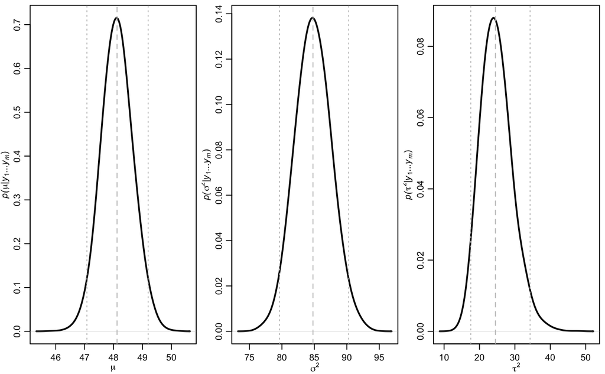

```r
# Plot - Marginal posterior of tau^2
plot(density(MST[,3],adj=2),xlab=expression(tau^2),main="",lwd=2,
ylab=expression(paste(italic("p("),tau^2,"|",italic(y[1]),"...",italic(y[m]),")")))
abline( v=quantile(MST[,3],c(.025,.5,.975)),col="gray",lty=c(3,2,3))
```

**POSTERIOR MEANS of** $\mu$, $\sigma^2$, $\tau^2$

```r
cat(paste("Post. Mean of mu:", mean((MST[,1]))))
```

```
Post. Mean of mu: 48.119131383854
```

```r
cat(paste("Post. Mean of sigma^2:", mean(sqrt(MST[,2]))))
```

```
Post. Mean of sigma^2: 9.20887127627761
```

```r
cat(paste("Post. Mean of tau^2:", mean(sqrt(MST[,3]))))
```

```
Post. Mean of tau^2: 4.96286641686435
```

**SHRINKAGE effect towards grand mean mu**

`theta.hat` is posterior means of $\theta_j$, i.e., the Bayesian estimate of $\theta_j$

```r
theta.hat <- apply(THETA,2,mean)
cat(paste("theta.hat:", theta.hat))
```

```
theta.hat: 50.5767619926411 theta.hat: 46.7098864998278 theta.hat: 48.6474135954593 theta.hat: 47.4477565833076 theta.hat: 38.2809503350711 theta.hat: 40.5927196604224 theta.hat: 41.7758837857651 theta.hat: 48.7425359030931 theta.hat: 48.9967639450452 theta.hat: 42.1933990525124 theta.hat: 55.555263…
```

```r
par(mfrow=c(1,2), mar=c(3,3,1,1), mgp=c(1.75,.75,0))

# Plot - ybar vs theta.hat
plot(ybar,theta.hat,xlab=expression(bar(italic(y))),ylab=expression(hat(theta)))
abline(0,1)
```

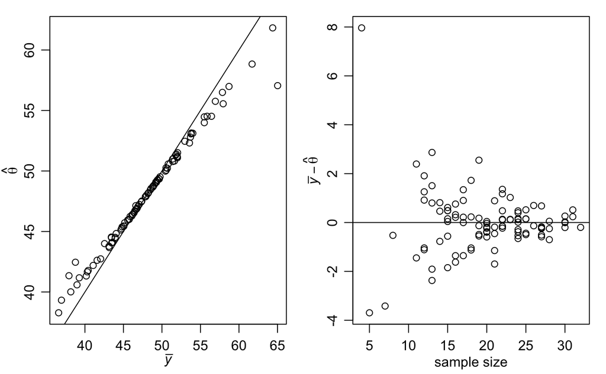

```r
# Plot - Differences between bayesian and frequentist estimates
plot(n,ybar-theta.hat,ylab=expression( bar(italic(y))-hat(theta) ),xlab="sample size")
abline(h=0)
```

**LEFT**: ybar on the $x$-axis (‘classical’ estimates, sample means per school) and theta.hat on the $y$-axis (Bayesian estimates). The slope of this line is $<1$, that is, high values of $ybar_j$ correspond to slightly less high values of the Bayesian estimates of $\theta_j$, and low values of $ybar_j$ correspond to slightly less low values of the Bayesian estimates of $\theta_j$. This is the **SHRINKAGE effect**.

**RIGHT**: group-specific sample sizes on the $x$-axis, and differences between frequentist and Bayesian estimates on the $y$-axis. Groups with low sample size get shrunk the most, whereas groups with large sample size hardly get shrunk at all. The larger the sample size for a group, the more information we have for that group and the less information we need to **BORROW** from the rest of the population.

$$\begin{align*}
\textrm{theta.hat}_j\approx E\left( \theta_j| \bar
y_j,\mu,\tau^2,\sigma^2\right) =
\frac{n_j/\sigma^2}{n_j/\sigma^2+1/\tau^2} \bar y_j &+
\frac{1/\tau^2}{n_j/\sigma^2+1/\tau^2} \mu\\
\bar y_j\textrm{ frequentist estimator of } \theta_j &\qquad \mu
\textrm{ prior mean of }\theta_j
\end{align*}$$

When $n_j$ is small, i.e. group $j$ gives little info about $\theta_j$, i.e. the frequentist estimate $\bar y_j$ is poor; however the Bayesian estimate:
$$E( \theta_j|
\ldots)\approx \mu$$
The Bayesian estimate is obtained borrowing strength from the other groups (through $\mu$)

When $\tau^2$ is large (heterogeneous groups), the Bayesian estimate:
$$E( \theta_j| \ldots)\approx \bar y_j$$

there is less shrinkage to $\mu$, relying more on the info in group $j$.

## Comparing schools

Let us plot the posterior CIs for each $\theta_j$, the group-specific parameters

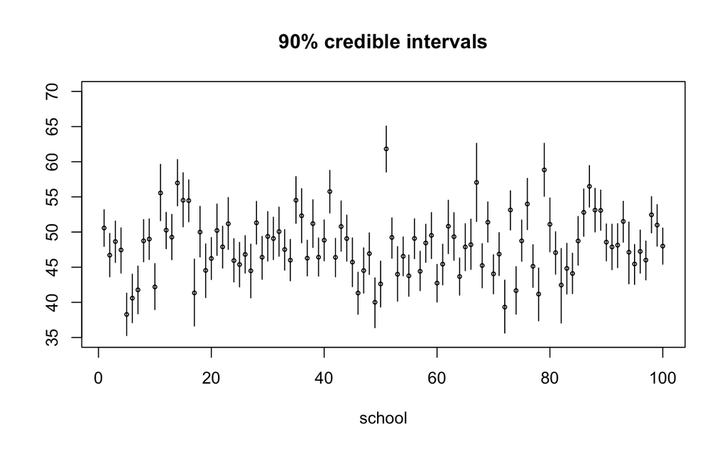

```r
# Plot - posterior CIs 90%
plot(1:100,theta.hat, cex=0.5,main="90% credible intervals",xlim=c(1,100),ylim=c(35,70),xlab='school',ylab='')
for (i in 1:100) {
probint=quantile(THETA[,i], c(0.05, 0.95))
lines(i * c(1, 1), probint)
}
```

- min of `theta.hat` is **SCHOOL 5**

```r
cat(paste("Worst school:", which.min(theta.hat)))
```

```
Worst school: 5
```

- max of `theta.hat` is **SCHOOL 51**

```r
#which(theta.hat==min(theta.hat)); which(theta.hat==max(theta.hat))
cat(paste("Best school:", which.max(theta.hat)))
```

```
Best school: 51
```

For each couple $(\theta_j, \theta_l)$, we compute the posterior probability that $\theta_j >\theta_l$, that is the **posterior prob that school** $j$ is BETTER than school $l$. Variable `better` store the matrix of these posterior probabilities

```r
compare.rates <- function(x) {
  nc <- 100
  ij <- as.matrix(expand.grid(1:nc, 1:nc))
  m <- as.matrix(x[,ij[,1]] > x[,ij[,2]])
  matrix(colMeans(m), nc, nc, byrow = TRUE)
}
better=compare.rates(THETA)
better
```

```
              [,1]        [,2]         [,3]         [,4]         [,5]         [,6]         [,7]       [,8]         [,9]
  [1,] 0.000000000 0.057666667 0.2083333333 0.0970000000 0.0000000000 0.0000000000 0.0000000000 0.21800000 0.2460000000
  [2,] 0.942333333 0.000000000 0.7730000000 0.6136666667 0.0010000000 0.0133333333 0.0410000000 0.77733333 0.8056666667
  [3,] 0.791666667 0.227000000 0.0000000000 0.3236666667 0.0000000000 0.0020000000 0.0056666667 0.51533333 0.5630000000
  [4,] 0.903000000 0.386333333 0.6763333333 0.0000000000 0.0000000000 0.0086666667 0.0216666667 0.69033333 0.7150000000
  [5,] 1.000000000 0.999000000 1.0000000000 1.0000000000 0.0000000000 0.7863333333 0.9023333333 1.00000000 1.0000000000
  [6,] 1.000000000 0.986666667 0.9980000000 0.9913333333 0.2136666667 0.0000000000 0.6570000000 0.99866667 0.9990000000
  [7,] 1.000000000 0.959000000 0.9943333333 0.9783333333 0.0976666667 0.3430000000 0.0000000000 0.99433333 0.9970000000
  [8,] 0.782000000 0.222666667 0.4846666667 0.3096666667 0.0000000000 0.0013333333 0.0056666667 0.00000000 0.5423333333
  [9,] 0.754000000 0.194333333 0.4370000000 0.2850000000 0.0000000000 0.0010000000 0.0030000000 0.45766667 0.0000000000
 [10,] 1.000000000 0.948666667 0.9930000000 0.9690000000 0.0650000000 0.2886666667 0.4503333333 0.99300000 0.9970000000
              [,10]      [,11]       [,12]       [,13]      [,14]     [,15]       [,16]        [,17]       [,18]        [,19]
  [1,] 0.0000000000 0.95866667 0.448000000 0.291666667 0.99466667 0.9186667 0.940666667 0.0023333333 0.414666667 0.0153333333
  [2,] 0.0513333333 0.99833333 0.927333333 0.828000000 1.00000000 0.9956667 0.998333333 0.0556666667 0.865333333 0.2410000000
  [3,] 0.0070000000 0.99000000 0.752000000 0.596666667 0.99766667 0.9796667 0.990666667 0.0193333333 0.681333333 0.0846666667
```

[output cut: 107 more lines]

### Some inference on SCHOOL 5

Posterior probability that **SCHOOL 5** is better than all the other schools:

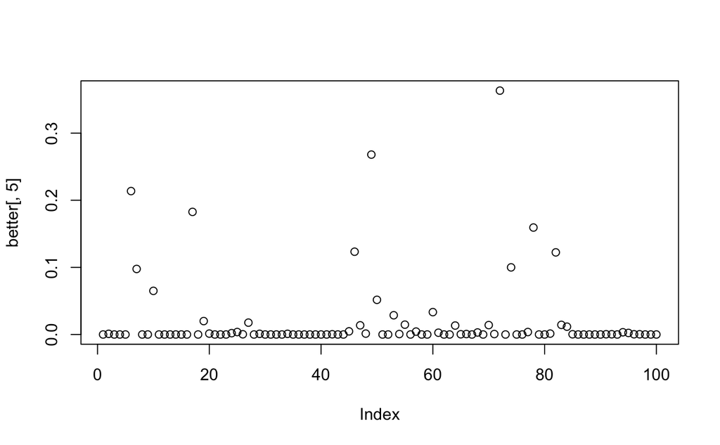

```r
# Plot - post probs of school 5 being better than other schools
plot(better[,5])
```

```r
# Post. probs of school 5 being better that other schools
cat(better[,5])
```

```
0 0.001 0 0 0 0.2136667 0.09766667 0 0 0.065 0 0 0 0 0 0 0.1826667 0 0.02 0.001333333 0 0 0 0.002 0.003666667 0.0003333333 0.01766667 0 0.001 0 0 0 0 0.001 0 0 0 0 0 0 0 0.0003333333 0 0 0.004666667 0.1233333 0.01366667 0.001333333 0.268 0.05166667 0 0 0.02866667 0.0006666667 0.01466667 0 0.00433333…
```

```r
# Min value
cat(paste("Min value:", min(better[-5,5])))
```

```
Min value: 0
```

```r
# Max Value
cat(paste("Max Value:", max(better[-5,5])))
```

```
Max Value: 0.363333333333333
```

All are $\leq 0.37$.

```r
# Post. prob. that school 5 is better than school 51
cat(paste("P(School 5 better than School 51 | data):", better[51,5]))
```

```
P(School 5 better than School 51 | data): 0
```

### Some inference on SCHOOL 51

Posterior probability that **SCHOOL 51** is better than all the other schools:

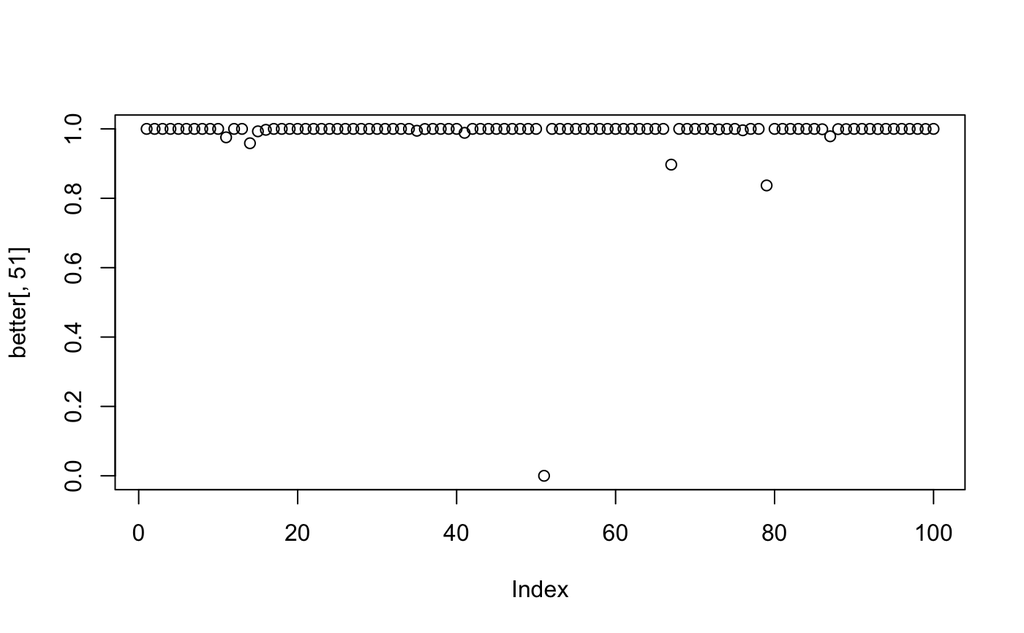

```r
# Plot - post probs of school 51 being better than other schools
plot(better[,51])
```

```r
# Post. probs of school 51 being better that other schools
cat(better[,51])
```

```
1 1 1 1 1 1 1 1 1 1 0.9756667 1 1 0.9586667 0.993 0.9973333 1 1 1 1 1 1 1 1 1 1 1 1 1 1 1 1 1 1 0.9946667 0.9996667 1 1 1 1 0.9886667 1 1 1 1 1 1 1 1 1 0 1 1 1 1 1 1 1 1 1 1 1 1 1 1 1 0.897 1 1 1 1 1 0.9986667 1 1 0.996 1 1 0.837 1 1 1 1 1 1 0.999 0.9786667 0.9993333 0.9993333 1 1 1 0.9996667 1 1 1 …
```

```r
# Min value
cat(paste("Min value:", min(better[-51,51])))
```

```
Min value: 0.837
```

```r
# Max Value
cat(paste("Max Value:", max(better[-51,51])))
```

```
Max Value: 1
```

```r
# Post. prob. that school 51 is better than school 5
cat(paste("P(School 51 better than School 5 | data):", better[5,51]))
```

```
P(School 51 better than School 5 | data): 1
```

### Inference on SCHOOL 46

We provide the same inference also for **SCHOOL 46**:

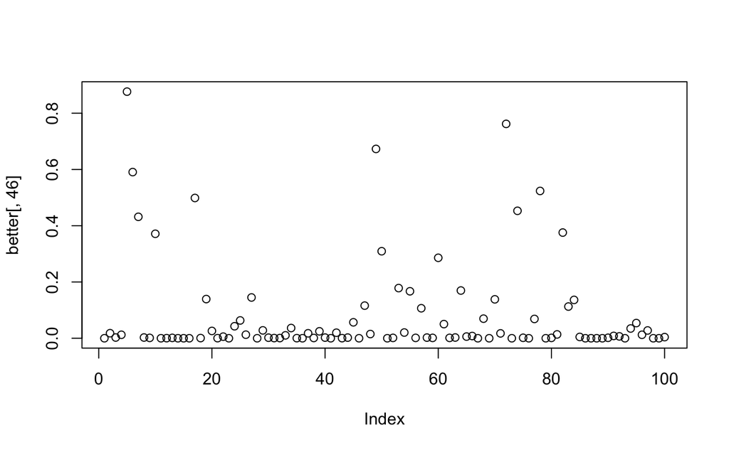

```r
# Plot - post probs of school 46 being better than other schools
plot(better[,46])
```

```r
# Post. probs of school 46 being better that other schools
cat(better[,46])
```

```
0 0.018 0.002666667 0.01233333 0.8766667 0.5906667 0.4316667 0.002666667 0.001333333 0.3713333 0 0.0003333333 0.001333333 0 0 0 0.4986667 0.0006666667 0.1393333 0.026 0.0003333333 0.005666667 0 0.04266667 0.06333333 0.01266667 0.145 0 0.028 0.002 0.0006666667 0.0006666667 0.01033333 0.03633333 0.000…
```

```r
# Min value
cat(paste("Min value:", min(better[-46,46])))
```

```
Min value: 0
```

```r
# Max Value
cat(paste("Max Value:", max(better[-46,46])))
```

```
Max Value: 0.876666666666667
```

**NOTE**  
According to the group sample averages, **SCHOOL 46** is better that **SCHOOL 82**:

```r
#  sample averages of schools 46 and 82
cat(paste("sample averages of school 46 and 82:", ybar[c(46,82)]))
```

```
sample averages of school 46 and 82: 40.1761904761905 sample averages of school 46 and 82: 38.764
```

but we are not considering uncertainty of the estimates; in fact the posterior probability that **SCHOOL 46** is better than **SCHOOL 82** is

```r
# Post. prob. that school 46 is better than school 82
cat(paste("P(School 46 better than 82 | data):", better[82,46]))
```

```
P(School 46 better than 82 | data): 0.375666666666667
```